# ПАРНАЯ ТОРГОВЛЯ (pairs trading)

## I) Введение

В статье "Гипотеза постоянного перелива" была описана стратегия парной торговли соотносимыми между собой активами. В развитие этой идеи проведено небольшое исследование, которое позволяет применять стратегию более научно обоснованно и математически выверено. Исследование помогает определить подходящие пары для такой торговли, способы их применения и ключевые метрики, на которые следует обращать внимание.

#### Load Packages

```python
import numpy as np
import pandas as pd
from sklearn.linear_model import LinearRegression
from statsmodels.tsa.stattools import adfuller
import scipy.stats as stats
from scipy.stats import norm
import matplotlib.pyplot as plt
import plotly
import requests
import datetime
import time
import os
```

#### Load Data

Загрузка исторических данных по монетам, которые нами были рассмотрены.

```python
def load_csv_to_dataframe(file_path):
    """Загружает CSV файл в DataFrame"""
    if os.path.exists(file_path):
        df = pd.read_csv(file_path)
        print(f"Data loaded from {file_path}")
        return df
    else:
        print(f"File {file_path} does not exist.")
        return None
```

```python
# STRK Data Load
file_path = "./starknet_2024-04-09_to_2024-10-06.csv"
strk_df = load_csv_to_dataframe(file_path)

# Вывод первых пяти строк загруженного DataFrame
if strk_df is not None:
    print(strk_df.head())
```

```
Data loaded from ./starknet_2024-04-09_to_2024-10-06.csv
     datetime      open      high       low     close
0  2024-04-09  1.892075  1.910474  1.892075  1.901451
1  2024-04-10  1.877495  1.881323  1.803202  1.863618
2  2024-04-11  1.857093  1.907494  1.826145  1.826145
3  2024-04-12  1.824520  1.854673  1.435422  1.508353
4  2024-04-13  1.524355  1.524355  1.291567  1.432814
```

```python
# ENA Data Load
file_path = "~/Documents/FinanceData/ethena_2024-04-02_to_2024-10-06.csv"
file_path = os.path.expanduser(file_path)  # Преобразуем путь с ~ в полный путь
ena_df = load_csv_to_dataframe(file_path)
```

```
Data loaded from /home/aka/Documents/FinanceData/ethena_2024-04-02_to_2024-10-06.csv
```

```python
# ZK Data Load
file_path = "./zksync_2024-06-17_to_2024-10-06.csv"
file_path = os.path.expanduser(file_path)  # Преобразуем путь с ~ в полный путь
zk_df = load_csv_to_dataframe(file_path)
```

```
Data loaded from ./zksync_2024-06-17_to_2024-10-06.csv
```

```python
# Wormhole Data Load
file_path = "~/Documents/FinanceData/wormhole_2024-04-03_to_2024-10-06.csv"
file_path = os.path.expanduser(file_path)  # Преобразуем путь с ~ в полный путь
w_df = load_csv_to_dataframe(file_path)
```

```
Data loaded from /home/aka/Documents/FinanceData/wormhole_2024-04-03_to_2024-10-06.csv
```

```python
# Set plotting options
%matplotlib inline
plt.rc('figure', figsize=(16, 9))
```

#### Подготовим таблицы для создания графика

```python
# Убедимся, что столбцы 'datetime' преобразованы к типу datetime
strk_df.loc[:, 'datetime'] = pd.to_datetime(strk_df['datetime'])
ena_df.loc[:, 'datetime'] = pd.to_datetime(ena_df['datetime'])
zk_df.loc[:, 'datetime'] = pd.to_datetime(zk_df['datetime'])
w_df.loc[:, 'datetime'] = pd.to_datetime(w_df['datetime'])

# Удалим дубликаты по столбцу 'datetime', если есть
strk_df = strk_df.drop_duplicates(subset=['datetime'])
ena_df = ena_df.drop_duplicates(subset=['datetime'])
zk_df = zk_df.drop_duplicates(subset=['datetime'])
w_df = w_df.drop_duplicates(subset=['datetime'])


# Объединяем данные по столбцу 'close' двух криптовалют
combined_df = pd.concat([strk_df[['datetime', 'close']].set_index('datetime'),
                         ena_df[['datetime', 'close']].set_index('datetime'),
                         zk_df[['datetime', 'close']].set_index('datetime'),
                         w_df[['datetime', 'close']].set_index('datetime')],
                        axis=1)

# Переименуем столбцы явно в соответствии с названиями криптовалют
combined_df.columns = ['STRK', 'ENA', 'ZK', 'W']
```

#### Создаем график данных четырех монет, которые, за исключением ZK, обладают схожей ликвидностью, капитализацией, временем выхода на рынок и, что самое главное, демонстрируют схожую динамику ценовых движений, что хорошо видно на самом графике.

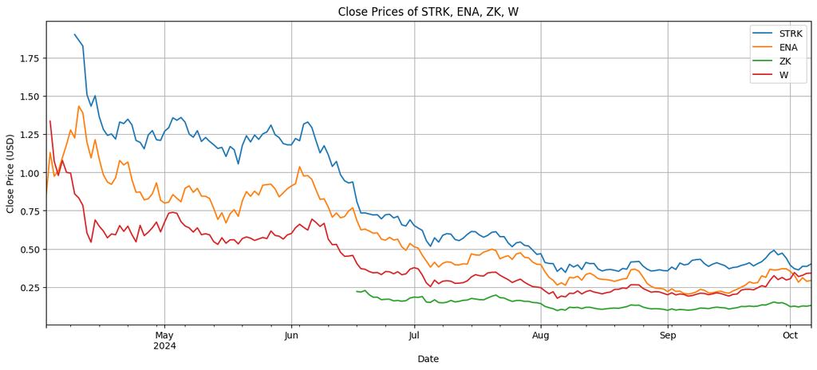

```python
# Строим график
combined_df.plot(figsize=(15, 6), title="Close Prices of STRK, ENA, ZK, W")

# Настраиваем оси и отображаем график
plt.xlabel('Date')
plt.ylabel('Close Price (USD)')
plt.grid(True)
plt.show()
```

Схожесть этих проектов позволила рассматривать их в прошлой статье как инструмент взаимного перелива ликвидности, однако требовались доказательства того, что сама стратегия и выбранные пары действительно эффективны. Именно для этого и было проведено дополнительное исследование.

Ответ на вопрос о работоспособности стратегии был получен быстро: она не является новаторской и уже давно применяется в торговле. Таким образом, основной вопрос заключался в другом — как использовать её максимально эффективно и насколько подходят пары, выбранные в предыдущей статье на основе визуального анализа графиков и спреда. Более точно, задача состоит в том, чтобы понять, как лучше всего находить пары активов для взаимной торговли и, опираясь на эти данные, оценить, насколько удачно были выбраны проекты в прошлый раз. Ниже представлен ход исследования и его результаты.

## II) Нормальное распределение

### 1) Введение

Самым простым показателем работоспособности спреда пары активов будет наличие в движении цен нормального распределения, которое, для напоминание, выгляет как на изображение ниже.

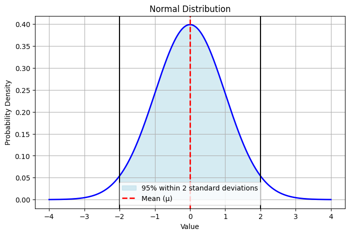

```python
# Параметры нормального распределения
mu = 0  # среднее значение
sigma = 1  # стандартное отклонение

# Создаем массив значений для оси X
x = np.linspace(mu - 4*sigma, mu + 4*sigma, 1000)
# Вычисляем плотность нормального распределения
y = norm.pdf(x, mu, sigma)

# Создаем график
plt.figure(figsize=(8, 5))
plt.plot(x, y, color='blue', lw=2)

# Область в пределах двух стандартных отклонений
plt.fill_between(x, y, where=((x >= mu - 2*sigma) & (x <= mu + 2*sigma)),
                 color='lightblue', alpha=0.5, label='95% within 2 standard deviations')

# Линии среднего и стандартных отклонений
plt.axvline(mu, color='red', linestyle='--', lw=2, label='Mean (μ)')
plt.axvline(mu - 2*sigma, color='black', linestyle='-', lw=1.5)
plt.axvline(mu + 2*sigma, color='black', linestyle='-', lw=1.5)

# Настройки графика
plt.title('Normal Distribution')
plt.xlabel('Value')
plt.ylabel('Probability Density')
plt.legend()
plt.grid(True)

# Отображаем график
plt.show()
```

Проверка спреда на нормальное распределение в парном трейдинге важна по нескольким причинам. Это помогает понять, насколько хорошо спред подходит для стратегий реверсии к среднему и для оценки вероятностей возможных движений спреда. Вот подробное объяснение, почему это важно:

#### 1. **Предсказуемость и реверсия к среднему**:

- **Стратегии реверсии к среднему** предполагают, что спред между активами имеет тенденцию возвращаться к своему среднему значению после отклонений.
- Если распределение спреда близко к нормальному, это означает, что его отклонения от среднего распределяются предсказуемо. В случае нормального распределения большинство значений (около 68%) находятся в пределах одного стандартного отклонения от среднего.
- Знание того, что спред нормально распределен, помогает лучше понимать вероятности возврата к среднему. Например, если спред отклонился на 2 стандартных отклонения от среднего, вероятность того, что он вернется, выше, если распределение нормальное.

#### 2. **Оценка риска и волатильности**:

- **Нормальное распределение** — это также стандартный метод в финансовой математике для оценки рисков, потому что оно позволяет использовать известные методы для оценки вероятностей.
- Например, в нормальном распределении мы знаем, что вероятность отклонения на 3 стандартных отклонения от среднего очень мала (около 0.3%). Это помогает трейдерам оценить риски при создании торговых стратегий.
- Если спред не имеет нормального распределения, это может указывать на наличие более частых резких движений (высокая хвостовость распределения) или асимметрию, что требует осторожности при оценке рисков.

#### 3. **Моделирование уровней открытия и закрытия позиций**:

- Когда спред имеет нормальное распределение, трейдеры (то есть мы) могут использовать параметры распределения (среднее и стандартное отклонение) для определения уровней входа и выхода из позиций.
- Например, можно настроить стратегию таким образом, чтобы открывать позиции, когда спред отклоняется на 2 стандартных отклонения от среднего, и закрывать их, когда он возвращается к среднему.
- Если спред отклоняется от нормальности (например, имеет длинные хвосты или сильно асимметричен), это может сделать такие стратегии менее эффективными, так как вероятность сильных отклонений от среднего выше, чем предполагается в нормальном распределении.

#### 4. **Проверка корректности модели и гипотез**:

- В парном трейдинге часто предполагается, что активы связаны линейной зависимостью, а спред между ними является стационарным. Но стационарность не обязательно означает нормальность.
- Проверка на нормальное распределение помогает понять, насколько эта гипотеза корректна. Если спред сильно отклоняется от нормальности, это может быть сигналом к пересмотру модели или поиску других подходящих активов для торговли.
- Например, если спред имеет асимметричное распределение или длинные хвосты, это может указывать на структурные особенности рынка или влияние внешних факторов, которые могут нарушить предположения вашей модели.

#### 5. **Нормальность и методы статистического анализа**:

- Многие статистические методы и тесты (включая тест Дики-Фуллера) предполагают нормальность временных рядов. Если спред близок к нормальному распределению, результаты таких тестов будут более надежными.
- Это особенно важно, если вы используете статистические методы для прогнозирования будущих движений или оценки вероятностей.

#### Как проверить нормальность:

Для проверки нормальности можно использовать такие тесты, как **тест Шапиро-Уилка**, **тест Жарка-Бера**, или просто построить **гистограмму** и **Q-Q график** (квантиль-квантиль график), чтобы визуально оценить, насколько распределение спреда близко к нормальному.

Перейдем тогда к анализу спредов на "нормальность" рассматриваемых нами пар, и начем с визуализации их спредов и графиков для визуального анализа.

### 2) Графический анализ

#### STRK/ENA

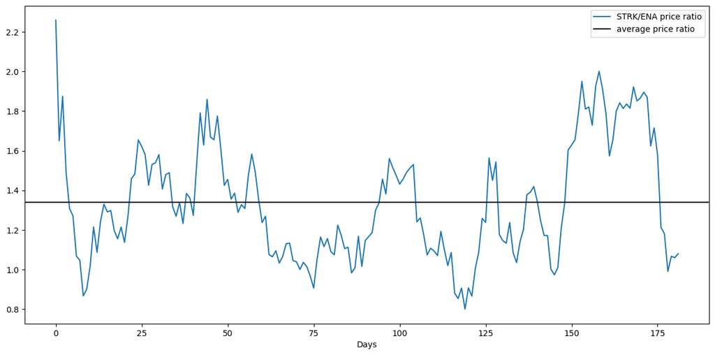

```
average price ratio 1.3390
```

```python
# Вычисляем соотношение цен закрытия
price_ratio_strk_ena = strk_df["close"] / ena_df["close"]

# Убираем строки с NaN
price_ratio_strk_ena = price_ratio_strk_ena.dropna()

# Строим график соотношения цен
price_ratio_strk_ena.plot(figsize=(15,7))

# Добавляем горизонтальную линию, соответствующую среднему значению
plt.axhline(price_ratio_strk_ena.mean(), color='black')

# Добавляем метки к осям и легенду
plt.xlabel('Days')
plt.legend(['STRK/ENA price ratio', 'average price ratio'])

# Отображаем график
plt.show()

# Выводим среднее соотношение
print(f"average price ratio {price_ratio.mean():.4f}")
```

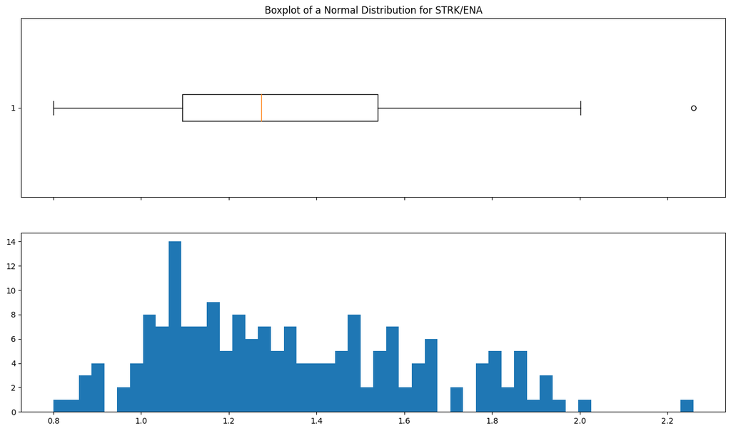

```python
fig, axes = plt.subplots(2, 1, figsize=(16, 9), sharex=True)
axes[0].boxplot(price_ratio_strk_ena, vert=False)
axes[1].hist(price_ratio_strk_ena, bins=50)
axes[0].set_title("Boxplot of a Normal Distribution for STRK/ENA");
```

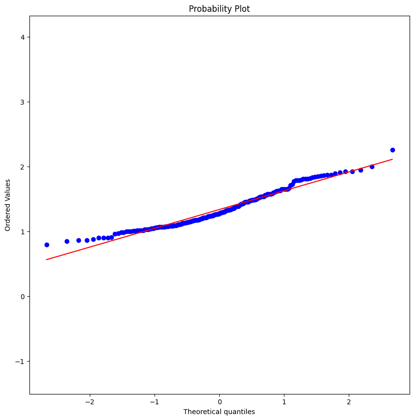

```python
# Q-Q plot of normally-distributed sample
plt.figure(figsize=(10, 10)); plt.axis('equal')
stats.probplot(price_ratio_strk_ena, dist='norm', plot=plt);
```

#### STRK/ZK

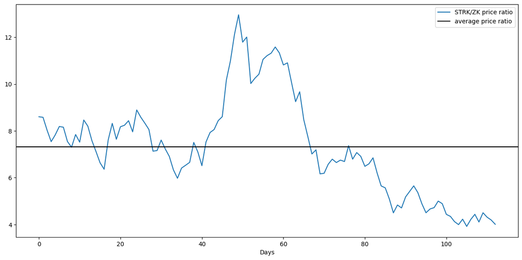

[output not shown]

```python
# Вычисляем соотношение цен закрытия
price_ratio_strk_zk = strk_df["close"] / zk_df["close"]

# Убираем строки с NaN
price_ratio_strk_zk = price_ratio_strk_zk.dropna()

# Строим график соотношения цен
price_ratio_strk_zk.plot(figsize=(15,7))

# Добавляем горизонтальную линию, соответствующую среднему значению
plt.axhline(price_ratio_strk_zk.mean(), color='black')

# Добавляем метки к осям и легенду
plt.xlabel('Days')
plt.legend(['STRK/ZK price ratio', 'average price ratio'])

# Отображаем график
plt.show()

# Выводим среднее соотношение
print(f"average price ratio {price_ratio.mean():.4f}")
```

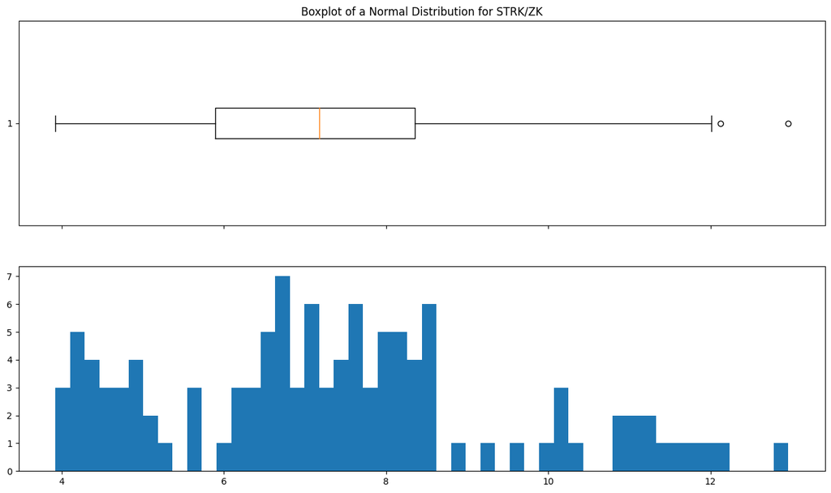

```python
fig, axes = plt.subplots(2, 1, figsize=(16, 9), sharex=True)
axes[0].boxplot(price_ratio_strk_zk, vert=False)
axes[1].hist(price_ratio_strk_zk, bins=50)
axes[0].set_title("Boxplot of a Normal Distribution for STRK/ZK");
```

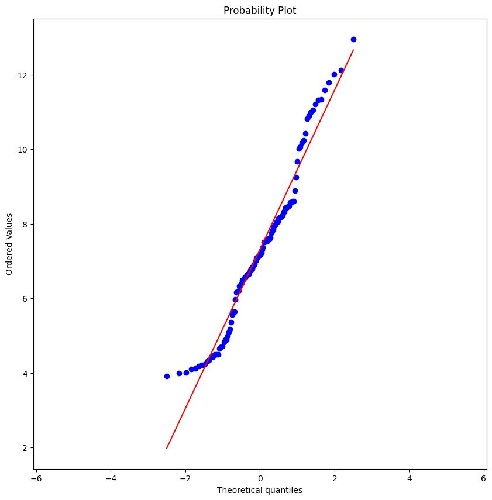

```python
# Q-Q plot of normally-distributed sample
plt.figure(figsize=(10, 10)); plt.axis('equal')
stats.probplot(price_ratio_strk_zk, dist='norm', plot=plt);
```

#### STRK/W

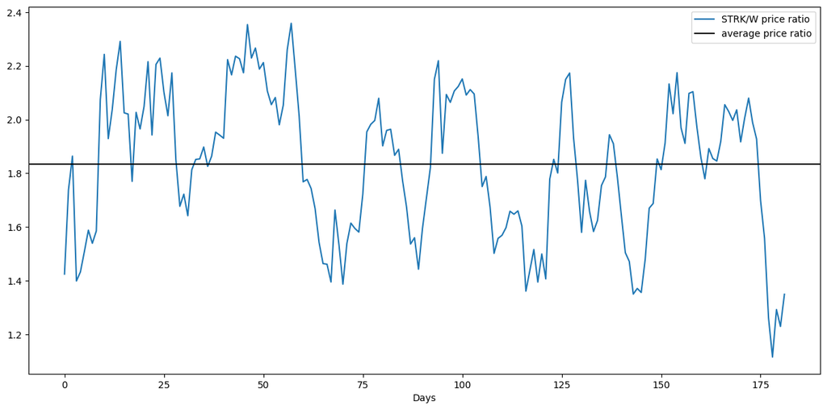

[output not shown]

```python
# Вычисляем соотношение цен закрытия
price_ratio_strk_w = strk_df["close"] / w_df["close"]

# Убираем строки с NaN
price_ratio_strk_w = price_ratio_strk_w.dropna()

# Строим график соотношения цен
price_ratio_strk_w.plot(figsize=(15,7))

# Добавляем горизонтальную линию, соответствующую среднему значению
plt.axhline(price_ratio_strk_w.mean(), color='black')

# Добавляем метки к осям и легенду
plt.xlabel('Days')
plt.legend(['STRK/W price ratio', 'average price ratio'])

# Отображаем график
plt.show()

# Выводим среднее соотношение
print(f"average price ratio {price_ratio.mean():.4f}")
```

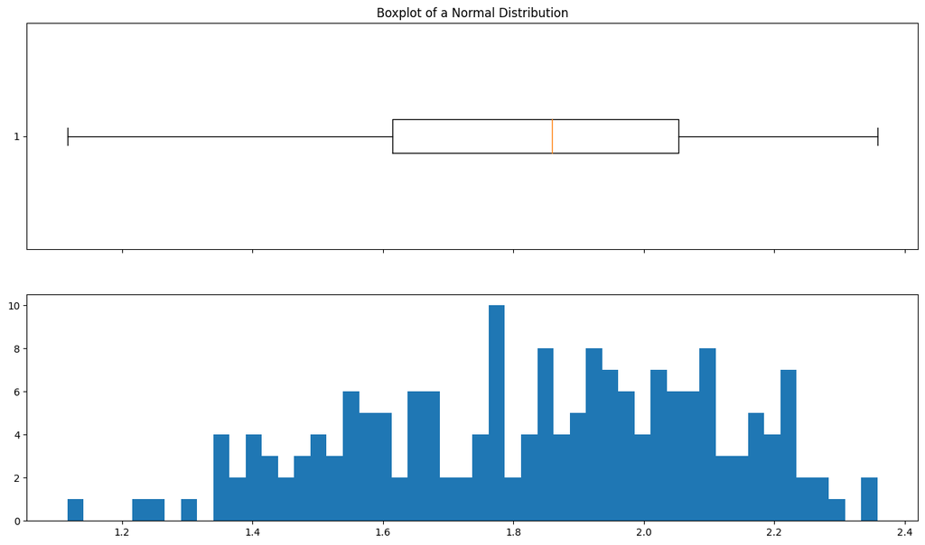

```python
fig, axes = plt.subplots(2, 1, figsize=(16, 9), sharex=True)
axes[0].boxplot(price_ratio_strk_w, vert=False)
axes[1].hist(price_ratio_strk_w, bins=50)
axes[0].set_title("Boxplot of a Normal Distribution");
```

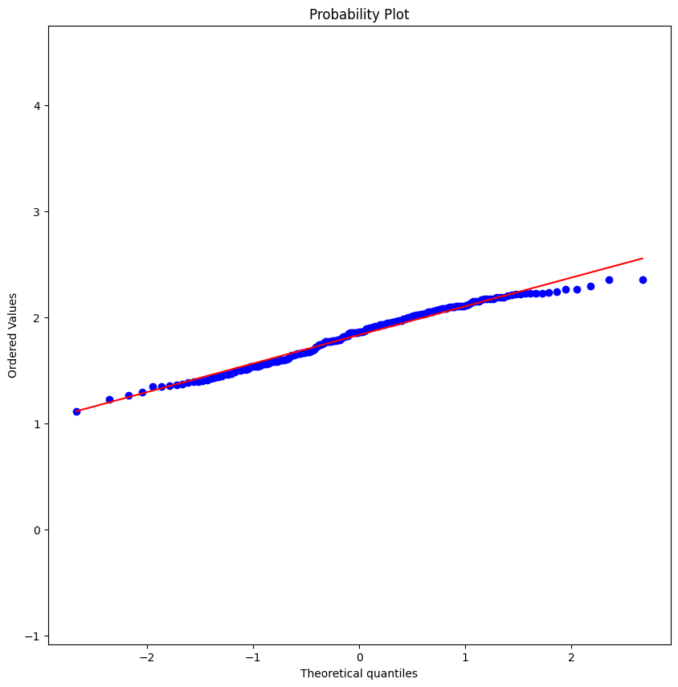

```python
# Q-Q plot of normally-distributed sample
plt.figure(figsize=(10, 10)); plt.axis('equal')
stats.probplot(price_ratio_strk_w, dist='norm', plot=plt);
```

#### Вывод

С точки зрения визуального анализа графиков, позволяющего оценить, насколько данные близки к нормальному распределению, можно сделать следующие выводы: пара STRK/ZK явно не соответствует нормальному распределению, тогда как пара STRK/W наиболее близка к нему, а пара STRK/ENA лишь c натяжкой соответствует характеристикам нормального распределения. Поэтому, несмотря на то, что пара STRK/ZK мне очень нравилась, её придется исключить из дальнейшего анализа. Оставшиеся две пары мы рассмотрим более детально в следующем этапе анализа.

### 3) Математическое тестирование на нормальность распределения

**Тест Шапиро-Уилка**

Тест Шапиро-Уилка доступен в библиотеке *scipy*. Нулевая гипотеза предполагает, что распределение данных является нормальным. Если p-значение больше выбранного уровня значимости (p-уровня), мы предполагаем, что распределение нормальное. В противном случае делаем вывод, что распределение не является нормальным.

```python
def is_normal(sample, test=stats.shapiro, p_level=0.05, **kwargs):
    """Apply a normality test to check if sample is normally distributed."""
    t_stat, p_value = test(sample, **kwargs)
    print("Test statistic: {}, p-value: {}".format(t_stat, p_value))
    print("Is the distribution Likely Normal? {}".format(p_value > p_level))
    return p_value > p_level
```

```python
# Using Shapiro-Wilk test (default)
print("STRK/ZK:-"); is_normal(price_ratio_strk_zk);
print("STRK/ENA:-"); is_normal(price_ratio_strk_ena);
print("STRK/W:-"); is_normal(price_ratio_strk_w);
```

```
STRK/ZK:-
Test statistic: 0.9577738046646118, p-value: 0.0013519112253561616
Is the distribution Likely Normal? False
STRK/ENA:-
Test statistic: 0.9604215621948242, p-value: 5.519179467228241e-05
Is the distribution Likely Normal? False
STRK/W:-
Test statistic: 0.9768590927124023, p-value: 0.0041700368747115135
Is the distribution Likely Normal? False
```

**Тест Колмогорова-Смирнова**

Тест Колмогорова-Смирнова доступен в библиотеке *scipy.stats*. Этот тест сравнивает распределение данных с теоретическим распределением. Мы выберем нормальное распределение ('norm') в качестве теоретического и зададим среднее и стандартное отклонение для этого распределения. Среднее и стандартное отклонение теоретической нормы будут равны среднему и стандартному отклонению фактического распределения данных.

```python
def is_normal_ks(sample, test=stats.kstest, p_level=0.05, **kwargs):
    """
    sample: a sample distribution
    test: a function that tests for normality
    p_level: if the test returns a p-value > than p_level, assume normality

    return: True if distribution is normal, False otherwise
    """
    normal_args = (np.mean(sample), np.std(sample))

    t_stat, p_value = test(sample, 'norm', normal_args, **kwargs)
    print("Test statistic: {}, p-value: {}".format(t_stat, p_value))
    print("Is the distribution Likely Normal? {}".format(p_value > p_level))
    return p_value > p_level
```

```python
# Using Shapiro-Wilk test (default)
print("STRK/ZK:-"); is_normal_ks(price_ratio_strk_zk);
print("STRK/ENA:-"); is_normal_ks(price_ratio_strk_ena);
print("STRK/W:-"); is_normal_ks(price_ratio_strk_w);
```

```
STRK/ZK:-
Test statistic: 0.09508798090675596, p-value: 0.24719689959827976
Is the distribution Likely Normal? True
STRK/ENA:-
Test statistic: 0.09127649526817483, p-value: 0.09201814768304717
Is the distribution Likely Normal? True
STRK/W:-
Test statistic: 0.06426831538117073, p-value: 0.42558241499344385
Is the distribution Likely Normal? True
```

## II) Стационарность спреда

**Стационарность** — это свойство временного ряда, при котором его статистические характеристики (например, среднее, дисперсия) не изменяются со временем. Основные признаки стационарного ряда:

- Постоянное среднее.
- Постоянная дисперсия (волатильность).
- Отсутствие тренда (временная зависимость между значениями ряда ограничена). Стационарные временные ряды проще анализировать и прогнозировать, так как их поведение не меняется в зависимости от времени.

**Стационарность спреда** означает, что отношение между двумя временными рядами, например, ценами двух активов, остается стабильной во времени и не демонстрирует тенденции к систематическому росту или падению.

Если спред стационарен:

- Он колеблется вокруг своего среднего значения.
- Имеет определенную степень предсказуемости (возвращается к среднему значению).
- Это может свидетельствовать о наличии долгосрочной равновесной связи между двумя активами. Например, цены двух акций могут быть связаны между собой через экономические или рыночные факторы, и их спред со временем стремится вернуться к некоторому равновесному уровню.

Если спред не стационарен:

- Он будет демонстрировать тренд, то есть может увеличиваться или уменьшаться с течением времени.
- Это может указывать на то, что между активами нет устойчивой долгосрочной связи, и разница между их ценами может увеличиваться без возврата к среднему уровню.

**Зачем проверять стационарность спреда?** Проверка стационарности спреда важна в парном трейдинге и других стратегиях, где предполагается, что спред между двумя активами будет возвращаться к среднему значению. Если спред стационарен, то можно использовать стратегии на основе торговли отклонений спреда от среднего значения.

Нормально распределённый и стационарный спред проще всего использовать в парном трейдинге, поскольку его цена колеблется вокруг среднего значения с предсказуемыми отклонениями.

В нашем исследовании для определения стационарности спреда мы будем использовать *расширенный тест Дики-Фуллера (Augmented Dickey-Fuller Test)*. Этот тест проверяет наличие единичного корня в временном ряде, что помогает определить, является ли ряд стационарным. Если тест отвергает нулевую гипотезу о наличии единичного корня, это свидетельствует о стационарности ряда, то есть его статистические свойства остаются стабильными во времени.

#### Augmented Dickey-Fuller Test

```python
def is_spread_stationary(spread, p_level=0.05):
    """
    spread: obtained from linear combination of two series with a hedge ratio

    p_level: level of significance required to reject null hypothesis of non-stationarity

    returns:
        True if spread can be considered stationary
        False otherwise
    """

    # Убираем NaN и бесконечные значения из спреда
    spread = spread.replace([np.inf, -np.inf], np.nan).dropna()

    # Используем adfuller для проверки стационарности
    adf_result = adfuller(spread, maxlag=None, regression='c', autolag='AIC', store=False, regresults=False)

    # Получаем p-value
    pvalue = adf_result[1]

    print(f"pvalue {pvalue:.4f}")
    if pvalue <= p_level:
        print(f"pvalue is <= {p_level}, assume spread is stationary")
        return True
    else:
        print(f"pvalue is > {p_level}, assume spread is not stationary")
        return False
```

```python
# Предположим, у вас уже есть рассчитанный спред:
is_stationary = is_spread_stationary(price_ratio_strk_ena)

# Результат функции (True/False) укажет, является ли спред стационарным:
if is_stationary:
    print("The spread is stationary, it may be suitable for mean-reverting strategies.")
else:
    print("The spread is not stationary, it may not be suitable for mean-reverting strategies.")
```

```
pvalue 0.0810
pvalue is > 0.05, assume spread is not stationary
The spread is not stationary, it may not be suitable for mean-reverting strategies.
```

```python
# Предположим, у вас уже есть рассчитанный спред:
is_stationary = is_spread_stationary(price_ratio_strk_w)

# Результат функции (True/False) укажет, является ли спред стационарным:
if is_stationary:
    print("The spread is stationary, it may be suitable for mean-reverting strategies.")
else:
    print("The spread is not stationary, it may not be suitable for mean-reverting strategies.")
```

```
pvalue 0.0009
pvalue is <= 0.05, assume spread is stationary
The spread is stationary, it may be suitable for mean-reverting strategies.
```

```python
# Предположим, у вас уже есть рассчитанный спред:
is_stationary = is_spread_stationary(price_ratio_strk_zk)

# Результат функции (True/False) укажет, является ли спред стационарным:
if is_stationary:
    print("The spread is stationary, it may be suitable for mean-reverting strategies.")
else:
    print("The spread is not stationary, it may not be suitable for mean-reverting strategies.")
```

```
pvalue 0.7635
pvalue is > 0.05, assume spread is not stationary
The spread is not stationary, it may not be suitable for mean-reverting strategies.
```

#### Вывод

С помощью теста на стационарность мы окончательно поняли, что только пара STRK/W из рассмотренных нами подходит для такой парной торговли.